# Bobs Burgers Tidy Tuesday

Brandon Brenes

2024-12-09

# Description

Using the **Bobs Burger Tidy Tuesday** data, we will be making a geom_point plot that has the regression equation and a trend line showing the relationship between _question/exclamation_ratios vs. *sentiment_variance*. We will display how this varies across seasons by assigning colors.

# Libraries and Load Data

```r
# library #
library(ggplot2)
library(dplyr)
library(patchwork)
library(ggpmisc)
library(kableExtra)
```

```r
# load data from tidy tuesday bobs burgers data #

raw_bob <- readr::read_csv('https://raw.githubusercontent.com/rfordatascience/tidytuesday/main/data/2024/2024-11-19/episode_metrics.csv')

# display #
head(raw_bob)
```

```
## # A tibble: 6 × 8
##   season episode dialogue_density avg_length sentiment_variance unique_words
##    <dbl>   <dbl>            <dbl>      <dbl>              <dbl>        <dbl>
## 1      1       1            0.930       37.5               3.32          960
## 2      1       2            0.994       33.8               3.99          950
## 3      1       3            0.992       31.1               4.08          915
## 4      1       4            0.994       32.2               3.71          892
## 5      1       5            0.994       34.1               3.78          888
## 6      1       6            0.994       33.2               3.30          921
## # ℹ 2 more variables: question_ratio <dbl>, exclamation_ratio <dbl>
```

# Data manipulation

We will clean up the data by making the episode a factor, selecting for the columns needed (season, episode, sentiment_variance, question_ratio, exclamation_ratio)

```r
# clean up raw data #

bob_data_clean <- raw_bob %>%
  mutate(episode = as.factor(episode)) %>%  # convert 'pisode to factor
  select(season, episode, sentiment_variance, question_ratio, exclamation_ratio)  # select  columns

# display on table #
bob_data_clean %>%
  head(6) %>%
  kable()
```

| season | episode | sentiment_variance | question_ratio | exclamation_ratio |
| --- | --- | --- | --- | --- |
| 1 | 1 | 3.324415 | 0.2079646 | 0.1924779 |
| 1 | 2 | 3.986799 | 0.1838384 | 0.1191919 |
| 1 | 3 | 4.075439 | 0.1754032 | 0.0987903 |
| 1 | 4 | 3.708638 | 0.1415094 | 0.1113208 |
| 1 | 5 | 3.778036 | 0.1641469 | 0.0626350 |
| 1 | 6 | 3.301975 | 0.1645833 | 0.0833333 |

# Plot

Using **ggplot** and **geom_point & geom_smooth**, we will create a point plot using the **bob_data_clean** data. We will also make season a color scale legend so we can visualize any change with time. We will do this for both the exclamation and question ratio. These plots will be combined into one and saved to ouputs

## Exclamation Ratio vs. Sentiment Variance

```r
# plot 1: exclamation ratio vs. sentiment variance
plot_exclamation <- ggplot(bob_data_clean, aes(x = exclamation_ratio, y = sentiment_variance, color = season)) +
    geom_point(size = 3, alpha = 0.8) +  # point plot
    geom_smooth(method = "lm", aes(group = 1), se = FALSE, color = "red") +
  # trendline in red
    stat_poly_eq(aes(label = paste(..eq.label.., ..rr.label.., sep = "~~~")),
                 formula = y ~ x,   # equation for regression analysis
                 parse = TRUE,
                 color = "red") +  # red text for equations
    theme_minimal(base_size = 14) +
    scale_color_viridis_c(name = "Season", option = "D") +
  # color scale for season gradient
    labs(
        x = "Exclamation Ratio",
        y = "Sentiment Variance"
    ) +
    theme(
        plot.title = element_text(hjust = 0.5, face = "bold"),
        axis.title = element_text(face = "bold", size = 10),  # bold axis titles
        axis.text = element_text(face = "bold"),  # bold axis texts
        legend.position = "none"  # remove individual legend from this plot
    )
```

## Question Ratio vs. Sentiment Variance

```r
# plot 2: question ratio vs. sentiment variance
plot_question <- ggplot(bob_data_clean, aes(x = question_ratio, y = sentiment_variance, color = season)) +
    geom_point(size = 3, alpha = 0.8) +  # point plot
    geom_smooth(method = "lm", aes(group = 1), se = FALSE, color = "red") +
  # trendline in red
    stat_poly_eq(aes(label = paste(..eq.label.., ..rr.label.., sep = "~~~")),
                 # equation for regression analysis
                 formula = y ~ x,
                 parse = TRUE,
                 color = "red") +  # red text for equations
    theme_minimal(base_size = 14) +
    scale_color_viridis_c(name = "Season", option = "D") +
  # color scale for season gradient
    labs(
        x = "Question Ratio",
        y = "Sentiment Variance"
    ) +
    theme(
        plot.title = element_text(hjust = 0.5, face = "bold"),
        axis.title = element_text(face = "bold", size = 10),  # bold axis titles
        axis.text = element_text(face = "bold"),  # bold axis texts
        legend.position = "none"  # remove individual legend from this plot
    )
```

## Combine the plots

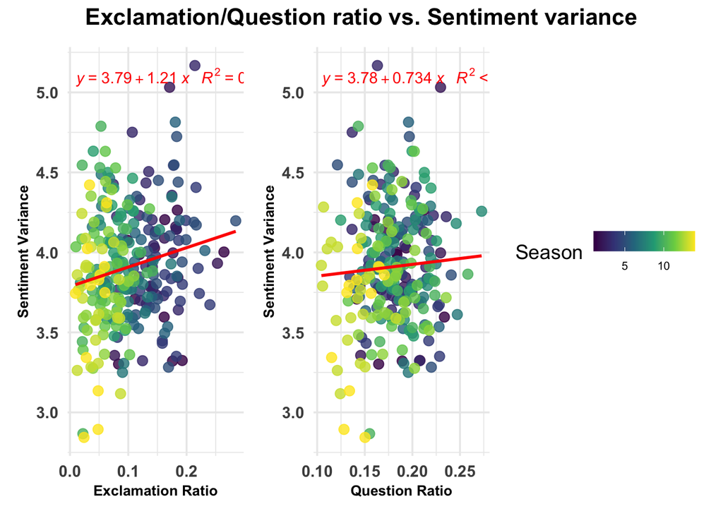

```r
combined_plot <- plot_exclamation + plot_question +
    plot_annotation(title = "Exclamation/Question ratio vs. Sentiment variance",
                    theme = theme(plot.title = element_text(hjust = 0.5, face = "bold", size = 16))) +
    plot_layout(guides = "collect") +  # collect the legends from both plots into one
    theme(legend.position = "bottom",  # place the legend at the bottom
          legend.key.size = unit(0.5, "cm"),  # make legend  smaller
          legend.text = element_text(size = 8))  # make text smaller
# display #
combined_plot
```

# What did I learn?

I learned how to use Rstudio to do a regression analysis while also displaying the equation and R^2 results on the graphs themselves. This is something I haven’t done in Rstudio before, prior to this I used excel. Now, of course, I realize that Rstudio can do this and so much more, making my life so much easier.